# PULVIRUS - GAM Dashboard

ISPRA division of Air Quality

Apr 2020

# Introduzione

Questa applicazione consente la visualizzazione interattiva dei risultati, delle principali statistiche descrittive e dei relativi grafici per le serie di dati valide (secondo i criteri stabiliti) del progetto PULVIRUS.

## Dati

Tutti i dati utilizzati per le analisi sono disponibili per il download attraverso *github* (pacchettizzati per R o in formato csv)

I dati sono relativi ai principali inquinanti atmosferici rilevati dalle stazioni appartenenti alle reti regionali di monitoraggio della qualità dell’aria, distribuite sul territorio nazionale, nello specifico: PM10, PM2.5, NO<sub>2</sub>

## Utilizzo dell’applicazione

Sono disponibili due metodi per selezionare la stazione di interesse: mappa e tabella. Cliccando sulla stazione dalla mappa o selezionando una riga dalla tabella vengono generati diversi plot, la tabella delle descrittive ed i risultati del modello GAM individuato per la stazione/inquinante.

Scegliendo una riga dalla tabella la mappa viene immediatamente centrata sul punto relativo nella mappa. Analogamente, scegliendo un punto sulla mappa la tabella viene filtrata per mostrare le informazioni sulla stazione. ed un *pop up* le riassume anche sulla mappa stessa.

I grafici vengono generati in automatico ad ogni modifica delle opzioni disponibili.

**IMPORTANTE**: i layer disponibili sulla mappa (Figura 1) mostrano soltanto le serie valide per le quali possono essere visualizzati i dati/risultati per l’inquinante scelto. Per visualizzare i dati/risultati è necessario selezionare l’inquinante dal menù a tendina/dropdown nel tab **“Plot”** (Figura 1a) che di fatto comanda rispetto a ciò che viene rappresentato sulla mappa.

[figure not shown]

Figura 1. Mappa

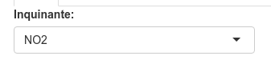

Figura 1a. Scelta inquinante

## Outputs

### Serie storica

Per rendere più chiaro l’andamento della serie nel corso degli anni viene prodotto un plot delle medie settimanali delle concentrazioni.

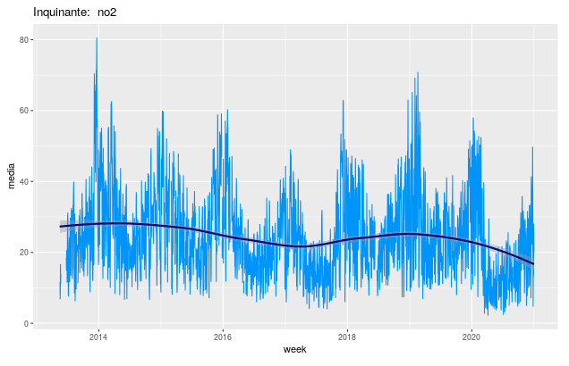

Figura 2. Serie delle medie settimanali

### Boxplot

I boxplot dei primi 6 mesi dell’anno, quelli di interesse per inizio e fine *lockdown*.

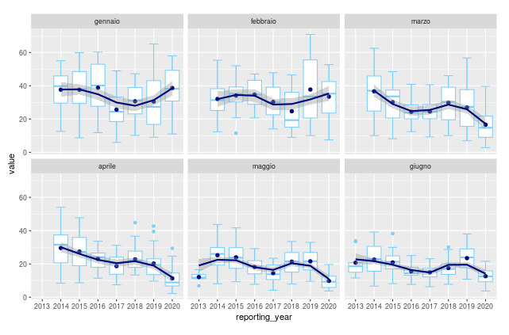

Figure 3. Boxplot con media e mediana.

### Pollution rose

E’ il tradizionale grafico della rosa dei venti che traccia la velocità e la direzione del vento a diversi intervalli prestabiliti, nella fattispecie l’anno. In questa versione la velocità del vento è sostituita dalla concentrazione dell’inquinante.

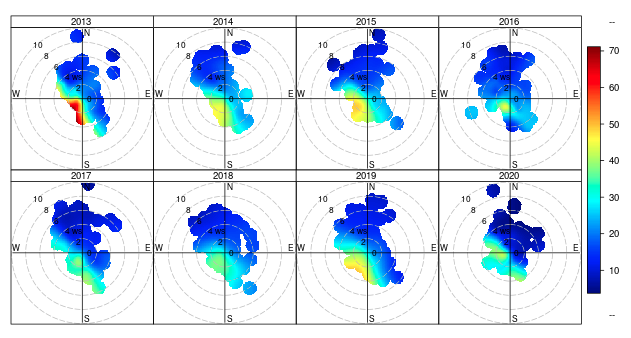

Figure 4. Pollution rose

### Polar plot

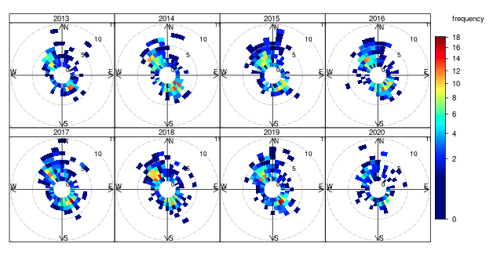

Figure 5. Polar plot

## Help & feedback

For additional help or to submit feedback or bug reports, please contact:  
ISPRA 06 5007 1 - pulvirus@isprambiente.it